## Loading the library

```r
library(tidyverse)
library(lubridate)
```

## Reading the CSV

```r
d_activity <- read.csv("C:/programming languages/R/Casestudy/dailyActivity_merged.csv")
d_calories <- read.csv("C:/programming languages/R/Casestudy/dailyCalories_merged.csv")

d_intensities <- read.csv("C:/programming languages/R/Casestudy/dailyIntensities_merged.csv")

d_steps <- read.csv("C:/programming languages/R/Casestudy/dailySteps_merged.csv")
```

## Getting a clear picture of loaded datasets

```r
glimpse(d_activity)
```

```
## Rows: 940
## Columns: 15
## $ Id                       <dbl> 1503960366, 1503960366, 1503960366, 150396036…
## $ ActivityDate             <chr> "4/12/2016", "4/13/2016", "4/14/2016", "4/15/…
## $ TotalSteps               <int> 13162, 10735, 10460, 9762, 12669, 9705, 13019…
## $ TotalDistance            <dbl> 8.50, 6.97, 6.74, 6.28, 8.16, 6.48, 8.59, 9.8…
## $ TrackerDistance          <dbl> 8.50, 6.97, 6.74, 6.28, 8.16, 6.48, 8.59, 9.8…
## $ LoggedActivitiesDistance <dbl> 0, 0, 0, 0, 0, 0, 0, 0, 0, 0, 0, 0, 0, 0, 0, …
## $ VeryActiveDistance       <dbl> 1.88, 1.57, 2.44, 2.14, 2.71, 3.19, 3.25, 3.5…
## $ ModeratelyActiveDistance <dbl> 0.55, 0.69, 0.40, 1.26, 0.41, 0.78, 0.64, 1.3…
## $ LightActiveDistance      <dbl> 6.06, 4.71, 3.91, 2.83, 5.04, 2.51, 4.71, 5.0…
## $ SedentaryActiveDistance  <dbl> 0, 0, 0, 0, 0, 0, 0, 0, 0, 0, 0, 0, 0, 0, 0, …
## $ VeryActiveMinutes        <int> 25, 21, 30, 29, 36, 38, 42, 50, 28, 19, 66, 4…
## $ FairlyActiveMinutes      <int> 13, 19, 11, 34, 10, 20, 16, 31, 12, 8, 27, 21…
## $ LightlyActiveMinutes     <int> 328, 217, 181, 209, 221, 164, 233, 264, 205, …
## $ SedentaryMinutes         <int> 728, 776, 1218, 726, 773, 539, 1149, 775, 818…
## $ Calories                 <int> 1985, 1797, 1776, 1745, 1863, 1728, 1921, 203…
```

```r
glimpse(d_calories)
```

```
## Rows: 940
## Columns: 3
## $ Id          <dbl> 1503960366, 1503960366, 1503960366, 1503960366, 1503960366…
## $ ActivityDay <chr> "4/12/2016", "4/13/2016", "4/14/2016", "4/15/2016", "4/16/…
## $ Calories    <int> 1985, 1797, 1776, 1745, 1863, 1728, 1921, 2035, 1786, 1775…
```

```r
glimpse(d_intensities)
```

```
## Rows: 940
## Columns: 10
## $ Id                       <dbl> 1503960366, 1503960366, 1503960366, 150396036…
## $ ActivityDay              <chr> "4/12/2016", "4/13/2016", "4/14/2016", "4/15/…
## $ SedentaryMinutes         <int> 728, 776, 1218, 726, 773, 539, 1149, 775, 818…
## $ LightlyActiveMinutes     <int> 328, 217, 181, 209, 221, 164, 233, 264, 205, …
## $ FairlyActiveMinutes      <int> 13, 19, 11, 34, 10, 20, 16, 31, 12, 8, 27, 21…
## $ VeryActiveMinutes        <int> 25, 21, 30, 29, 36, 38, 42, 50, 28, 19, 66, 4…
## $ SedentaryActiveDistance  <dbl> 0, 0, 0, 0, 0, 0, 0, 0, 0, 0, 0, 0, 0, 0, 0, …
## $ LightActiveDistance      <dbl> 6.06, 4.71, 3.91, 2.83, 5.04, 2.51, 4.71, 5.0…
## $ ModeratelyActiveDistance <dbl> 0.55, 0.69, 0.40, 1.26, 0.41, 0.78, 0.64, 1.3…
## $ VeryActiveDistance       <dbl> 1.88, 1.57, 2.44, 2.14, 2.71, 3.19, 3.25, 3.5…
```

```r
glimpse(d_steps)
```

```
## Rows: 940
## Columns: 3
## $ Id          <dbl> 1503960366, 1503960366, 1503960366, 1503960366, 1503960366…
## $ ActivityDay <chr> "4/12/2016", "4/13/2016", "4/14/2016", "4/15/2016", "4/16/…
## $ StepTotal   <int> 13162, 10735, 10460, 9762, 12669, 9705, 13019, 15506, 1054…
```

## Finding the customers who are unique to dataset

```r
n_distinct(d_activity$Id)
```

```
## [1] 33
```

```r
n_distinct(d_calories$Id)
```

```
## [1] 33
```

```r
n_distinct(d_intensities$Id)
```

```
## [1] 33
```

```r
n_distinct(d_steps$Id)
```

```
## [1] 33
```

## Judging the duplicate values to remove them

```r
sum(duplicated(d_activity))
```

```
## [1] 0
```

```r
sum(duplicated(d_calories))
```

```
## [1] 0
```

```r
sum(duplicated(d_intensities))
```

```
## [1] 0
```

```r
sum(duplicated(d_steps))
```

```
## [1] 0
```

## Adding additional datasets to load and see what values can be explored

```r
d_sleep <- read.csv("C:/programming languages/R/Casestudy/sleepDay_merged.csv")

h_steps <- read.csv("C:/programming languages/R/Casestudy/hourlySteps_merged.csv")

h_calories <- read.csv("C:/programming languages/R/Casestudy/hourlyCalories_merged.csv")
```

## Getting the clear picture of new datasets

```r
glimpse(d_sleep)
```

```
## Rows: 413
## Columns: 5
## $ Id                 <dbl> 1503960366, 1503960366, 1503960366, 1503960366, 150…
## $ SleepDay           <chr> "4/12/2016 12:00:00 AM", "4/13/2016 12:00:00 AM", "…
## $ TotalSleepRecords  <int> 1, 2, 1, 2, 1, 1, 1, 1, 1, 1, 1, 1, 1, 1, 1, 1, 1, …
## $ TotalMinutesAsleep <int> 327, 384, 412, 340, 700, 304, 360, 325, 361, 430, 2…
## $ TotalTimeInBed     <int> 346, 407, 442, 367, 712, 320, 377, 364, 384, 449, 3…
```

```r
glimpse(h_steps)
```

```
## Rows: 22,099
## Columns: 3
## $ Id           <dbl> 1503960366, 1503960366, 1503960366, 1503960366, 150396036…
## $ ActivityHour <chr> "4/12/2016 12:00:00 AM", "4/12/2016 1:00:00 AM", "4/12/20…
## $ StepTotal    <int> 373, 160, 151, 0, 0, 0, 0, 0, 250, 1864, 676, 360, 253, 2…
```

```r
glimpse(h_calories)
```

```
## Rows: 22,099
## Columns: 3
## $ Id           <dbl> 1503960366, 1503960366, 1503960366, 1503960366, 150396036…
## $ ActivityHour <chr> "4/12/2016 12:00:00 AM", "4/12/2016 1:00:00 AM", "4/12/20…
## $ Calories     <int> 81, 61, 59, 47, 48, 48, 48, 47, 68, 141, 99, 76, 73, 66, …
```

## Seeing unique customers

```r
n_distinct(d_sleep$Id)
```

```
## [1] 24
```

```r
n_distinct(h_steps$Id)
```

```
## [1] 33
```

```r
n_distinct(h_calories$Id)
```

```
## [1] 33
```

## Finding duplicate values

```r
sum(duplicated(d_sleep))
```

```
## [1] 3
```

```r
sum(duplicated(h_steps))
```

```
## [1] 0
```

```r
sum(duplicated(h_calories))
```

```
## [1] 0
```

## Dropping the null data

```r
d_activity <- d_activity %>% distinct() %>% drop_na()

d_sleep <- d_sleep %>% distinct() %>% drop_na()

h_steps <- h_steps %>% distinct() %>% drop_na()

h_calories <- h_calories %>%  distinct() %>% drop_na()
```

## Renaming the complete dataset to lower caps

```r
d_activity <- rename_with(d_activity,tolower)

d_sleep <- rename_with(d_sleep,tolower)

h_steps <- rename_with(h_steps,tolower)

h_calories <- rename_with(h_calories,tolower)
```

## Making the date time consistent

```r
d_activity <- d_activity %>% rename(date=activitydate) %>% mutate(date=as_date(date,format="%m/%d/%Y"))

d_sleep <- d_sleep %>% rename(date=sleepday) %>% mutate(date=as_date(date,format="%m/%d/%Y %I:%M:%S %p", tz=Sys.timezone()))
h_steps <- h_steps %>% rename(date=activityhour) %>% mutate(date=as.POSIXct(date,format="%m/%d/%Y %I:%M:%S %p", tz=Sys.timezone()))

h_calories <- h_calories %>% rename(date=activityhour) %>% mutate(date=as.POSIXct(date,format="%m/%d/%Y %I:%M:%S %p", tz=Sys.timezone()))
```

## Merging the datasets for complete analysis & making an aspect of dividing customers on basis of their use of our app

```r
d_ac_sleep <- merge(d_activity,d_sleep,by=c("id","date"))

d_use <- d_ac_sleep %>% group_by(id) %>% summarize(days=sum(n())) %>% mutate(use_level=case_when(days>=1 & days<=5 ~ "Low Use", days>=6 & days<=15 ~ "Moderate Use", days>=16 & days<=31 ~ "High Use"))

print(d_use)
```

```
## # A tibble: 24 × 3
##            id  days use_level
##         <dbl> <int> <chr>
##  1 1503960366    25 High Use
##  2 1644430081     4 Low Use
##  3 1844505072     3 Low Use
##  4 1927972279     5 Low Use
##  5 2026352035    28 High Use
##  6 2320127002     1 Low Use
##  7 2347167796    15 Moderate Use
##  8 3977333714    28 High Use
##  9 4020332650     8 Moderate Use
## 10 4319703577    26 High Use
## # … with 14 more rows
```

## Getting the percentage of users segmented on basis of usage of our app

```r
d_use_per <- d_use %>% group_by(use_level) %>% summarize(total=n()) %>% mutate(totals=sum(total)) %>% group_by(use_level) %>% summarize(total_per=total/totals)

print(d_use_per)
```

```
## # A tibble: 3 × 2
##   use_level    total_per
##   <chr>            <dbl>
## 1 High Use         0.542
## 2 Low Use          0.333
## 3 Moderate Use     0.125
```

## Pie chart for a visual of users

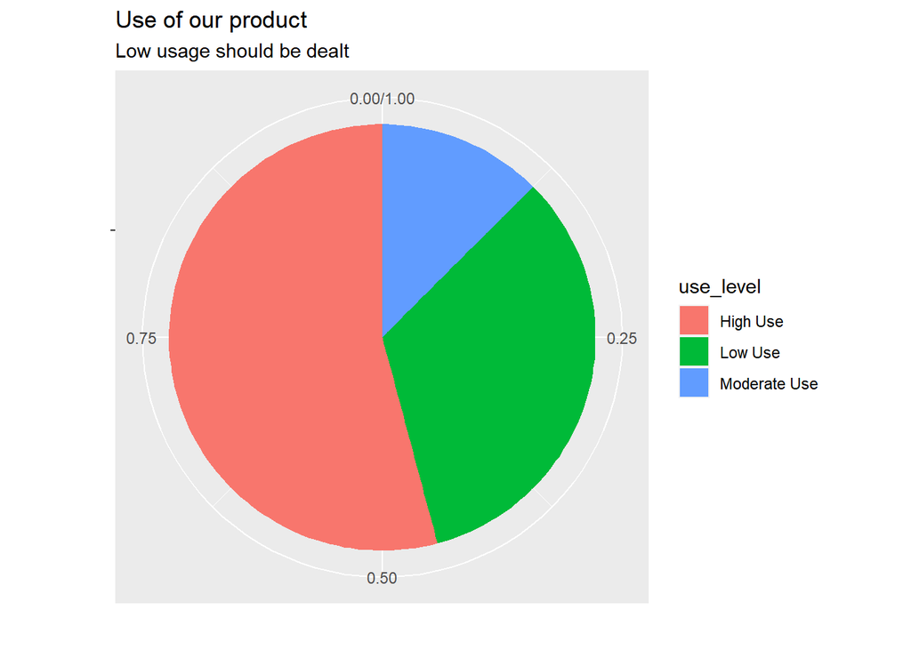

```r
ggplot(data=d_use_per,aes(x="",y=total_per,fill=use_level))+geom_col()+coord_polar(theta="y")+ labs(title = "Use of our product",subtitle ="Low usage should be dealt",x="",y="")
```

## Formatting the data based on days of week

```r
d_ac_sleep <- d_ac_sleep %>% mutate(weekday=weekdays(date))

d_ac_sleep$weekday <- ordered(d_ac_sleep$weekday, levels=c("Monday","Tuesday","Wednesday","Thursday", "Friday","Saturday","Sunday"))
```

## Finding mean of total steps and total sleep minutes users take day-wise

```r
d_steps_sleep <- d_ac_sleep %>% group_by(weekday) %>% summarize(weeks_steps=mean(totalsteps),weeks_sleep=mean(totalminutesasleep))
```

## Plotting it with ranges depicted from red to green color, with red being lowest

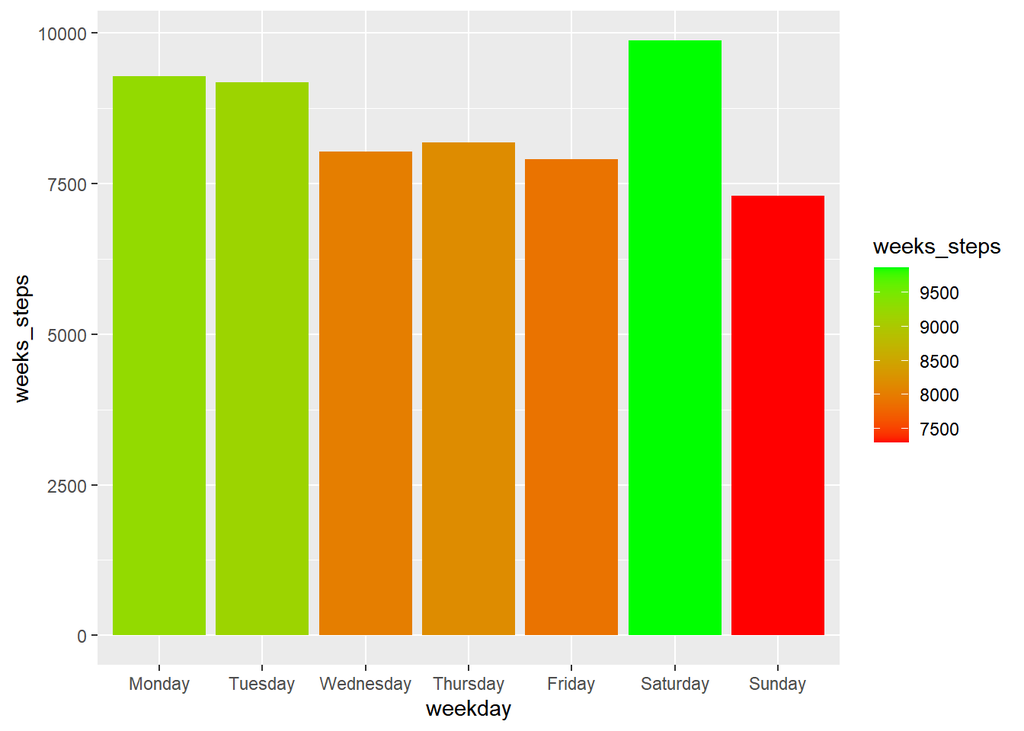

```r
ggplot(d_steps_sleep)+geom_col(aes(x=weekday,y=weeks_steps,fill=weeks_steps))+ scale_fill_gradient(low="red",high="green")
```

## Plotting it with ranges depicted from red to green color, with red being lowest

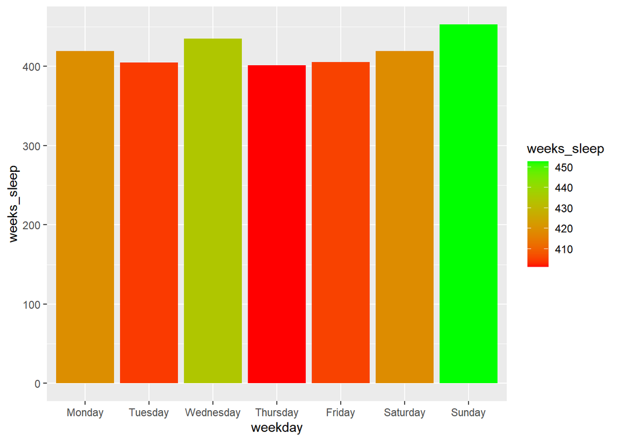

```r
ggplot(d_steps_sleep)+geom_col(aes(x=weekday,y=weeks_sleep,fill=weeks_sleep))+ scale_fill_gradient(low="red",high="green")
```

## Seperating the date and time and then merging to get a clear understanding

```r
h_steps <- h_steps %>% separate(date,into=c("date","time"),sep=" ") %>% mutate(date=ymd(date))

h_calories <- h_calories %>% separate(date,into=c("date","time"),sep=" ") %>% mutate(date=ymd(date))

h_cal_steps <- merge(h_calories,h_steps,by=c("id","date","time"))
```

## Seeing the relation of steps with calories

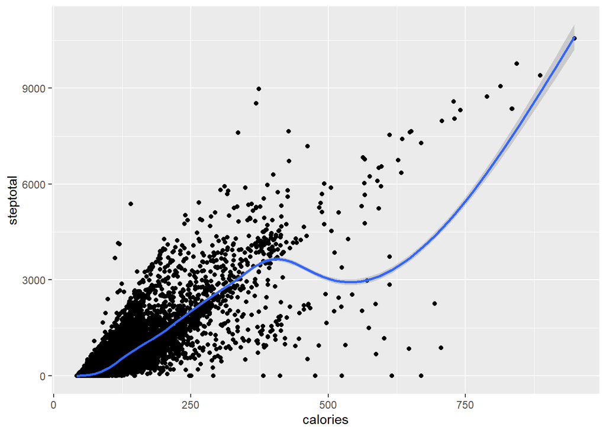

```r
ggplot(h_cal_steps,aes(x=calories,y=steptotal))+geom_point()+geom_smooth()
```

## Loading the weight dataset

```r
w_log <- read.csv("C:/programming languages/R/Casestudy/weightLogInfo_merged.csv")
```

## Getting the clear dataset picture

```r
glimpse(w_log)
```

```
## Rows: 67
## Columns: 8
## $ Id             <dbl> 1503960366, 1503960366, 1927972279, 2873212765, 2873212…
## $ Date           <chr> "5/2/2016 11:59:59 PM", "5/3/2016 11:59:59 PM", "4/13/2…
## $ WeightKg       <dbl> 52.6, 52.6, 133.5, 56.7, 57.3, 72.4, 72.3, 69.7, 70.3, …
## $ WeightPounds   <dbl> 115.9631, 115.9631, 294.3171, 125.0021, 126.3249, 159.6…
## $ Fat            <int> 22, NA, NA, NA, NA, 25, NA, NA, NA, NA, NA, NA, NA, NA,…
## $ BMI            <dbl> 22.65, 22.65, 47.54, 21.45, 21.69, 27.45, 27.38, 27.25,…
## $ IsManualReport <chr> "True", "True", "False", "True", "True", "True", "True"…
## $ LogId          <dbl> 1.462234e+12, 1.462320e+12, 1.460510e+12, 1.461283e+12,…
```

## Finding dataset for distinct customers

```r
n_distinct(w_log$Id)
```

```
## [1] 8
```

## Find sum of duplicated data

```r
sum(duplicated(w_log))
```

```
## [1] 0
```

## Lower caps with column names

```r
w_log <- rename_with(w_log,tolower)
```

## Formatting dataset for the date column and seperating date and time

```r
w_log <- w_log %>% mutate(date=as.POSIXct(date,format="%m/%d/%Y %I:%M:%S %p", tz=Sys.timezone()))

w_log <- w_log %>% separate(date,into=c("date","time"),sep=" ") %>% mutate(date=ymd(date))
```

## Create a boxplot

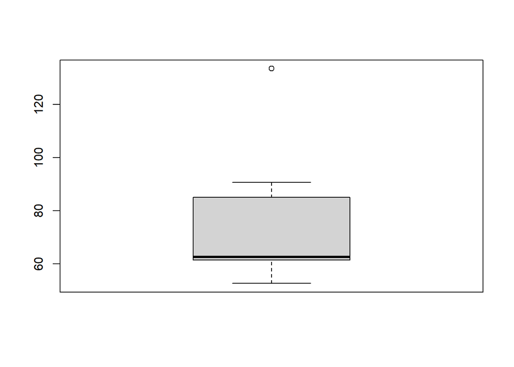

```r
boxplot.default(w_log$weightkg)
```

## Removing outliers

```r
library(dplyr)
w_log <- subset(w_log,weightkg<120)
```

## Merging data sets

```r
h_cal_steps2 <- h_cal_steps %>% group_by(id,date) %>% summarize(total_cal= sum(calories),total_steps=sum(steptotal),.groups='drop')

w_log_cal_Steps <- merge(w_log,h_cal_steps2,by=c("id","date"))
```

## Plotting total_cal and weight to find corrleation

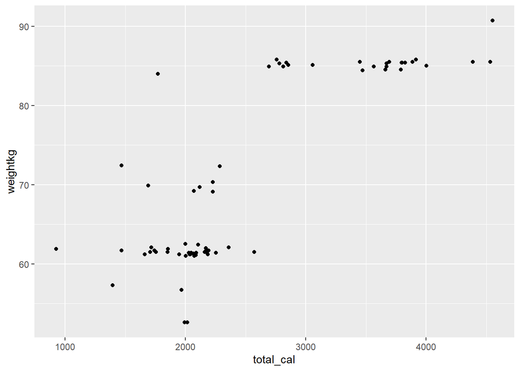

```r
ggplot(data=w_log_cal_Steps)+geom_point(mapping=aes(total_cal,weightkg))
```

## Seeing the correlation

```r
cor(w_log_cal_Steps$total_cal,w_log_cal_Steps$weightkg)
```

```
## [1] 0.8291217
```

# CONCLUSIONS

### 1. Since maximum users use our app well,there is still 33.33 % using our app in less usage

### 2. People on sunday tend to sleep more than walking

### 3. Calories burnt and people having steps are positively correlated

# RECOMMENDATIONS

### 1. Awarness can be made among users with less engagement about health benifits to turn users into high use

### 2. To engage people more on sunday, some extra benifits be given so that people have healthy lifestyle

### 3. Towards week ends near to thursday people take less sleep so more sleep can be encouraged by providing users stress busting excersises.